# Early Earth — heavy-atom fragment sizes

Additional views of the 3,521 hot/independent-quench pairs and their emitted-string catalog.

### How much of the size change involves non-hydrogen atoms? — F19

**Point:** the mean over every fragment rises **12.56%**, while the mean among fragments containing non-H atoms rises **0.55%**. Hydrogen-only fragments contribute zeros to the first mean; their mean per-frame share falls from **22.39% to 13.15%**. Largest non-H counts are 42 hot / 43 quenched; maxima usually stay unchanged.

Heavy = C + N + O here. **Keep original fragment membership**, even when H bridges heavy atoms; counting H as zero does not delete it from connectivity. Dotted line: restart. All 3,521 production pairs; original-DCD hot and independent quenched endpoints. The canonical-coordinate analogue of F12 is available in exploration.

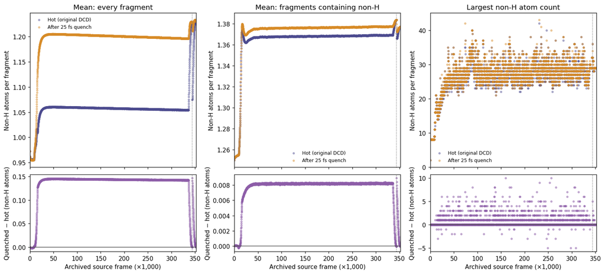

### Do heavy-atom sizes tell the same variety-versus-abundance story? — F20

**Point:** median size is **11 non-H atoms** for distinct strings, but **one** for repeated fragment occurrences. Each series has its own denominator. Default: exclude H-only fragments from all three distributions; set `INCLUDE_H_ONLY = True` to retain their zero-size bin. H-only fragments supply 22.44% / 13.25% of pooled hot/quenched occurrences. These pooled shares differ from mean per-frame shares.

The complete union includes non-carbon heavy fragments. Strings are representations, not confirmed species; occurrences are repeated observations, not yields.

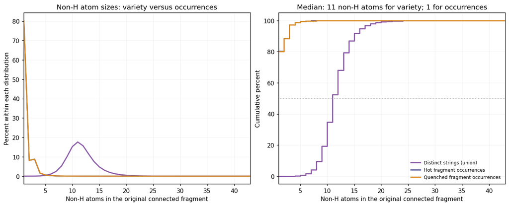